# Understanding the Profile Information of a Loan Borrower

## Investigation Overview

In this investigation, I wanted to understand the profile information of a loan borrower.

## Dataset Overview

This data set contains 113,937 observations with 81 variables of which the majority are numeric. The attributes used in this analysis are 'term', 'loanstatus', 'listingcategory (numeric)', 'borrowerstate', 'occupation', 'employmentstatus', 'employmentstatusduration', 'isborrowerhomeowner', 'statedmonthlyincome', 'loanoriginalamount', 'monthlyloanpayment', 'investmentfromfriendscount', 'investors'.

## Loan Status

Majority of the Loans are Current (>50000), followed by Completed (>30000) and Chargedoff (>10000) caps off top three.

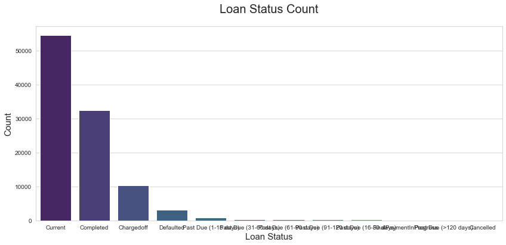

## Borrowers State

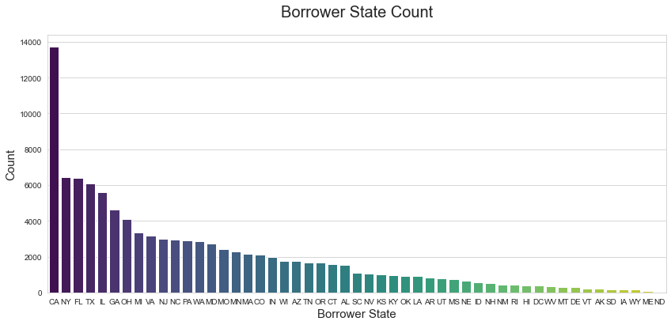

## Employment Status

Majority of the borrowers are Employed. Full-time employees makes the biggest percentage of the employed borrowes. At the bottom, the Retired tends to borrow less.

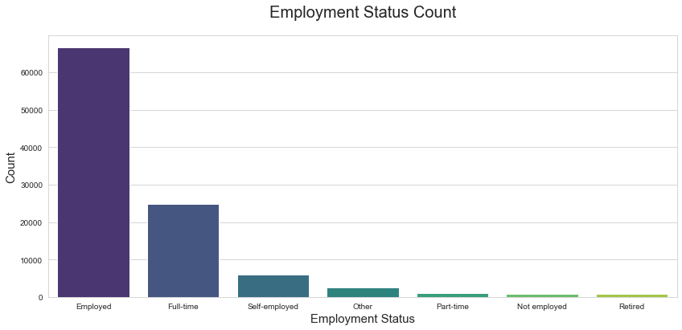

## Monthly Loan Payment vs Loan Original Amount

Monthly loan payment is positively correlated to loan original amount.

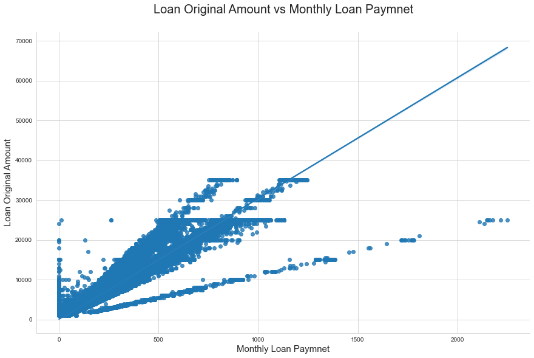

## Monthly loan payment and Loan original amount grouped by loan Term

As much as the monthly loan paymnet is positively correlated to the loan original amount, it is interesting to note that there is a variance as per the steepness of the correlation. Loans with term limits of 12 tends to get lower loan original amount with a higher repayment amount compared to long term loans (60 months) which has a higher loan original amount with a lower monthly repayment amount.

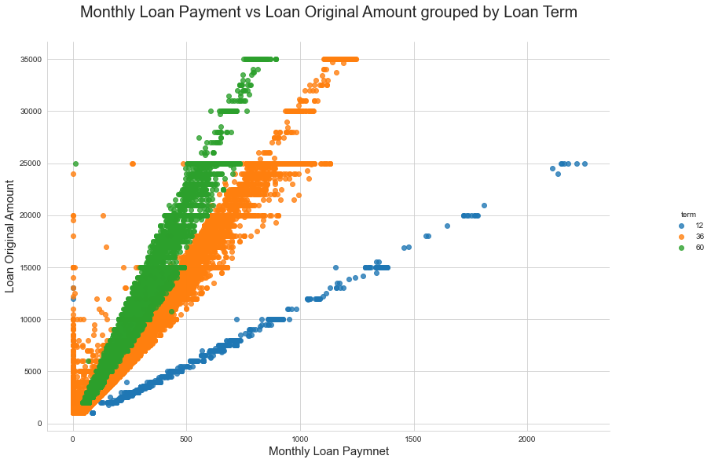

## Conclusion

> From this analysis, we can conclude that:

[output not shown]